# Phase2

MohammadAli Olama , 98100497

2/10/2022

# part i

first read the file :

```r
a = read.csv("lyon_housing.csv" , encoding = "UTF-8")
```

sort it with respect to date_transaction and then its price :

```r
a = a[order(a$date_transaction , a$price),]
head(a)
```

|  | date_transaction | type_purchase | type_property | rooms_count | surface_housing | surface_effective_usable | surface_terrain | parkings_count | price | address | district | latitude | longitude | date_construction |
| --- | --- | --- | --- | --- | --- | --- | --- | --- | --- | --- | --- | --- | --- | --- |
| 3555 | 16/07/01 | ancien | appartement | 1 | 25 | 25.97 | 0 | 1 | 62000 | 17 AV ROGER SALENGRO | Villeurbanne | 45.77535 | 4.868801 | 15/12/02 11:38 |
| 34983 | 16/07/01 | ancien | appartement | 1 | 39 | 37.63 | 0 | 0 | 79000 | 280 AV BERTHELOT | Lyon 8e Arrondissement | 45.73846 | 4.862189 | 90/01/01 0:00 |
| 27454 | 16/07/01 | VEFA | appartement | 1 | 21 | 21.42 | 0 | 0 | 80000 | 1 RUE BECHEVELIN | Lyon 7e Arrondissement | 45.75433 | 4.842729 | 90/01/01 0:00 |
| 28577 | 16/07/01 | ancien | appartement | 1 | 23 | 20.59 | 0 | 0 | 86500 | 29 RUE CHEVREUL | Lyon 7e Arrondissement | 45.74925 | 4.838652 | 90/01/01 0:00 |
| 12407 | 16/07/01 | ancien | appartement | 1 | 27 | NA | 0 | 0 | 87000 | 5 RUE PORT DU TEMPLE | Lyon 2e Arrondissement | 45.76090 | 4.832115 | 90/01/01 0:00 |
| 16312 | 16/07/01 | ancien | appartement | 2 | 34 | NA | 0 | 1 | 90000 | 11 RUE DE MONTBRILLANT | Lyon 3e Arrondissement | 45.74993 | 4.871085 | 90/01/01 0:00 |

let’s see how many invalid or NA values are there in the data set per column:

```r
colSums(is.na(a))
```

```
##         date_transaction            type_purchase            type_property
##                        0                        0                        0
##              rooms_count          surface_housing surface_effective_usable
##                        0                        0                    14491
##          surface_terrain           parkings_count                    price
##                        0                        0                        0
##                  address                 district                 latitude
##                        0                        0                      143
##                longitude        date_construction
##                      143                        0
```

it seems that more than 35% of samples suffer from lack of “surface_effective_usable” value. now if we replace this unknown values with other values(e.g mean or median or …) we may produce a great error terms. so it’s better to think we don’t have this column and use other columns.

also 143 houses don’t have latitude - longitude values. we can skip this houses in our calculations(if we need to use their location). because we have about 40516 samples and 143 is small in relative to 40516.

at first, we remove “suface_effective_useable” column from all samples. this column contains about 14000 missing values so it is not useable for us.

second we exclude samples with longitude or latitude missing values(143 samples)

```r
effective_usable = a$surface_effective_usable
a = a[,c(1:5 , 7:14)]
a= a[complete.cases(a) , ]
```

then read json file of stations:

```r
stations = fromJSON(file = "station_coordinates.json")
namess = c()
longitudes = c()
latitudes= c()
group = c()
models = c()
for (i in 1:11){
  AA = stations[i]
  AA = as.data.frame(AA)
  di = dim(AA)
  for (j in 1:di[1]){
    namess = append(namess , AA[j,1])
    longitudes = append(longitudes , AA[j,3])
    latitudes = append(latitudes , AA[j,2])
    group= append(group , i)
    if (i<=4){
      models = append(models , "train")
    }else{
      models = append(models , "tramva")
    }
  }
}

stations = data.frame(namess , latitudes , longitudes , group , models)
stations$models = as.factor(stations$models)
stations$group = as.factor(stations$group)
colnames(stations) = c("name" , "latitude" , "longitude" , "group" , "model")
```

```r
head(stations)
```

| name | latitude | longitude | group | model |
| --- | --- | --- | --- | --- |
| Ampère - Victor Hugo | 45.75305 | 4.829160 | 1 | train |
| Cordeliers | 45.76339 | 4.835823 | 1 | train |
| Cusset | 45.76564 | 4.900848 | 1 | train |
| Flachet - Alain Gilles | 45.76778 | 4.889377 | 1 | train |
| Foch | 45.76879 | 4.844304 | 1 | train |
| Gratte-Ciel | 45.76905 | 4.882311 | 1 | train |

map of the stations :

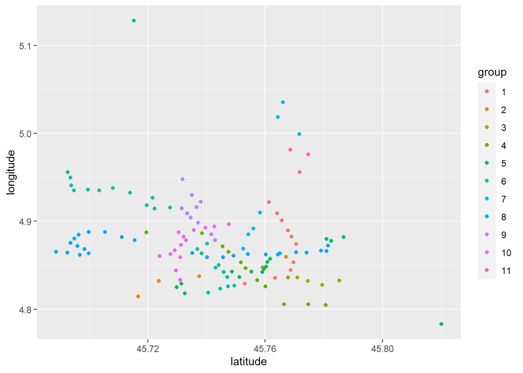

```r
ggplot(data = stations)+geom_point(mapping = aes(x=latitude,y=longitude, color=group))
```

lets add 3 more columns.these columns show the date of transaction in year, month, day. we will use them as categorical values.

```r
d = as.POSIXct(a$date_transaction , format="%Y/%m/%d")
y =format(d , format="%Y")
m = format(d , format="%m")
d = format(d , format="%d")
for (i in 16:21){
  st1 = paste("00" ,i , sep = "")
  st2 = paste("20" ,i , sep = "")
  y[y==st1] = st2
}

a$year = as.character(y)
a$month = as.character(m)
a$day = as.character(d)
```

and add 3 more columns.these columns show the date of construction in year, month, day. we will use them as categorical values:

```r
d2 = as.POSIXct(a$date_construction , format="%Y/%m/%d")
y2 =format(d2 , format="%Y")
m2 = format(d2 , format="%m")
d2 = format(d2 , format="%d")
for (i in 0:9){
  st1 = paste("000" ,i , sep = "")
  st2 = paste("200" ,i , sep = "")
  y2[y2==st1] = st2
}
for (i in 10:23){
  st1 = paste("00" ,i , sep = "")
  st2 = paste("20" ,i , sep = "")
  y2[y2==st1] = st2
}
for (i in 85:99){
  st1 = paste("00" ,i , sep = "")
  st2 = paste("19" ,i , sep = "")
  y2[y2==st1] = st2
}

a$cons_year = as.character(y2)
a$cons_month = as.character(m2)
a$cons_day = as.character(d2)
```

and add 1 more columns.these column shows the distance of each house to its nearest station(kilometers).

```r
di =dim(stations)
a$station_distance = rep(Inf , each=40373)

for (i in 1:di[1]){
  lat1 = a$latitude
  lat2 = stations$latitude[i]
  lat1 = lat1 / ((180/pi))
  lat2 = lat2 / ((180/pi))

  lon1 = a$longitude
  lon2 = stations$longitude[i]

  lon1 = lon1 / ((180/pi))
  lon2 = lon2 / ((180/pi))

  d = 3963.0 * acos((sin(lat1) * sin(lat2)) + cos(lat1) * cos(lat2) * cos(lon2-lon1))
  d = 1.609344 * d
  d2 = pmin(a$station_distance , d)
  a$station_distance = d2
}
```

```r
head(a)
```

|  | date_transaction | type_purchase | type_property | rooms_count | surface_housing | surface_terrain | parkings_count | price | address | district | latitude | longitude | date_construction | year | month | day | cons_year | cons_month | cons_day | station_distance |
| --- | --- | --- | --- | --- | --- | --- | --- | --- | --- | --- | --- | --- | --- | --- | --- | --- | --- | --- | --- | --- |
| 3555 | 16/07/01 | ancien | appartement | 1 | 25 | 0 | 1 | 62000 | 17 AV ROGER SALENGRO | Villeurbanne | 45.77535 | 4.868801 | 15/12/02 11:38 | 2016 | 07 | 01 | 2015 | 12 | 02 | 0.3796220 |
| 34983 | 16/07/01 | ancien | appartement | 1 | 39 | 0 | 0 | 79000 | 280 AV BERTHELOT | Lyon 8e Arrondissement | 45.73846 | 4.862189 | 90/01/01 0:00 | 2016 | 07 | 01 | 1990 | 01 | 01 | 0.0900611 |
| 27454 | 16/07/01 | VEFA | appartement | 1 | 21 | 0 | 0 | 80000 | 1 RUE BECHEVELIN | Lyon 7e Arrondissement | 45.75433 | 4.842729 | 90/01/01 0:00 | 2016 | 07 | 01 | 1990 | 01 | 01 | 0.1107929 |
| 28577 | 16/07/01 | ancien | appartement | 1 | 23 | 0 | 0 | 86500 | 29 RUE CHEVREUL | Lyon 7e Arrondissement | 45.74925 | 4.838652 | 90/01/01 0:00 | 2016 | 07 | 01 | 1990 | 01 | 01 | 0.2779234 |
| 12407 | 16/07/01 | ancien | appartement | 1 | 27 | 0 | 0 | 87000 | 5 RUE PORT DU TEMPLE | Lyon 2e Arrondissement | 45.76090 | 4.832115 | 90/01/01 0:00 | 2016 | 07 | 01 | 1990 | 01 | 01 | 0.3997575 |
| 16312 | 16/07/01 | ancien | appartement | 2 | 34 | 0 | 1 | 90000 | 11 RUE DE MONTBRILLANT | Lyon 3e Arrondissement | 45.74993 | 4.871085 | 90/01/01 0:00 | 2016 | 07 | 01 | 1990 | 01 | 01 | 0.3405319 |

let’s talk about columns of this dataset :

## columns

#### data_transacton:

this column ranges from 2016/07/01 to 2021/06/30. we will plot a map of houses acording to their location with respect to their year of transaction later.

#### type_purchase:

type_purchase : it’s a 2-state factor variable with values “ancien” and “VEFA”

```r
table(a$type_purchase)
```

```
##
## ancien   VEFA
##  35419   4954
```

#### type_property:

it’s a 2-state factor variable with values “appartement” and “maison”

```r
table(a$type_property)
```

```
##
## appartement      maison
##       39700         673
```

#### rooms_count:

it’s an integer value variable ranges from 1 to 6 rooms.

```r
table(a$rooms_count)
```

```
##
##     1     2     3     4     5     6
##  6007 10929 12576  7765  2518   578
```

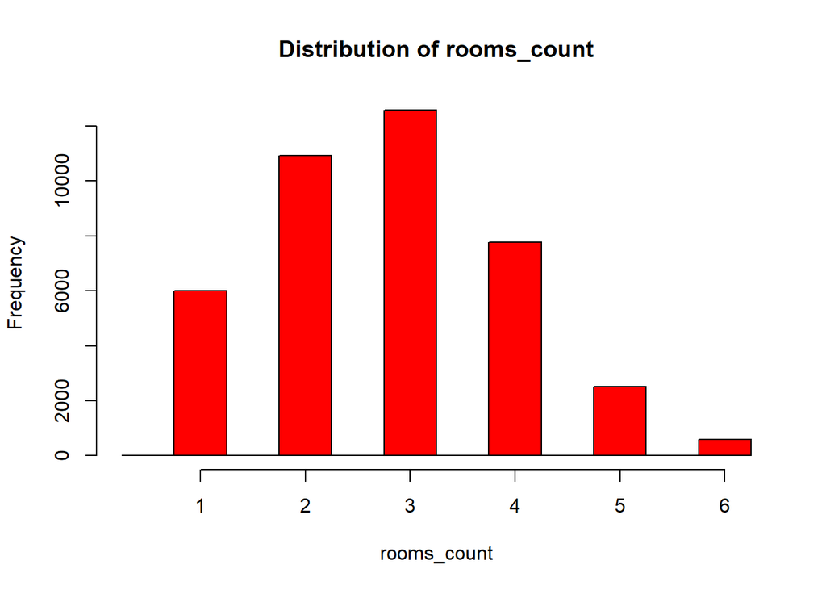

```r
hist(a$rooms_count ,main="Distribution of rooms_count",xlab = "rooms_count", col="red", breaks = seq(0.25 , 6.5 , 0.5))
```

#### surface_housing:

it’s an integer value variable ranges from 20 to 300

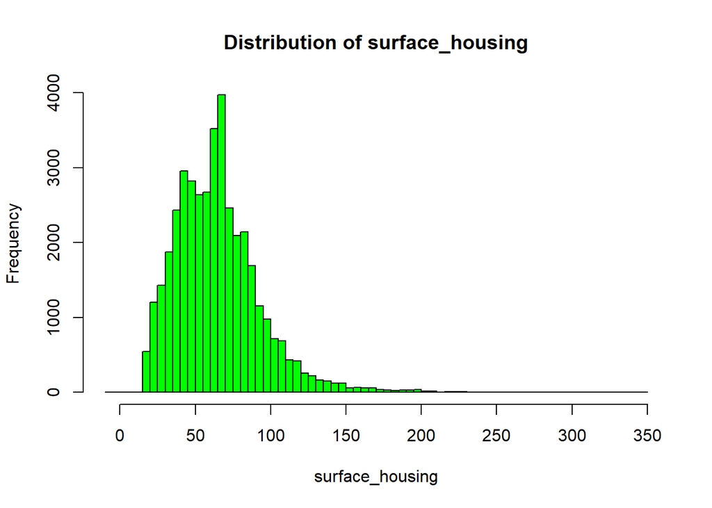

```r
hist(a$surface_housing , breaks = seq(-10,350 , 5) , col="green" , main="Distribution of surface_housing" , xlab = "surface_housing")
```

the mean and standard error of this column is:

```r
mea = mean(a$surface_housing)
s = sd(a$surface_housing)

print(paste("mean=" , mea , ", sd=" , s))
```

```
## [1] "mean= 65.2218561910187 , sd= 28.2248195700634"
```

now if we plot it and match a normal curve on it :

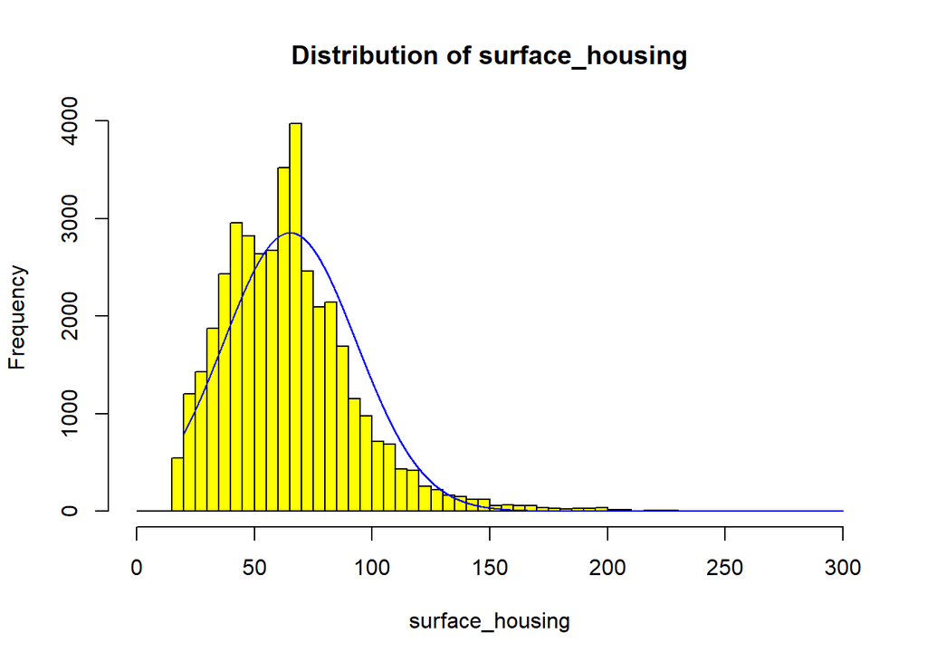

```r
var = var(a$surface_housing)
his = hist(a$surface_housing , breaks = seq(0,300,5) , col="yellow" , main="Distribution of surface_housing" , xlab = "surface_housing")
xfit = seq(min(a$surface_housing) , max(a$surface_housing) , length=length(a$surface_housing))
yfit = dnorm(xfit , mean = mea, sd = s) * diff(his$mids[1:2] * length(a$surface_housing))

lines(xfit , yfit , col="blue" , )
```

#### surface_effective_usable:

it’s float value variable ranges from 2.81(!) to 270.

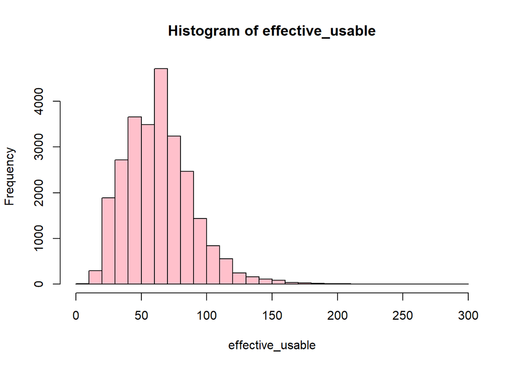

```r
hist(effective_usable , breaks = seq(0,300 , 10) , col = "pink")
```

we saw in previous assumptions that this columns seems to be useless (because of great number of NA in it) and so we have removed it from dataset.

#### surface_terrain:

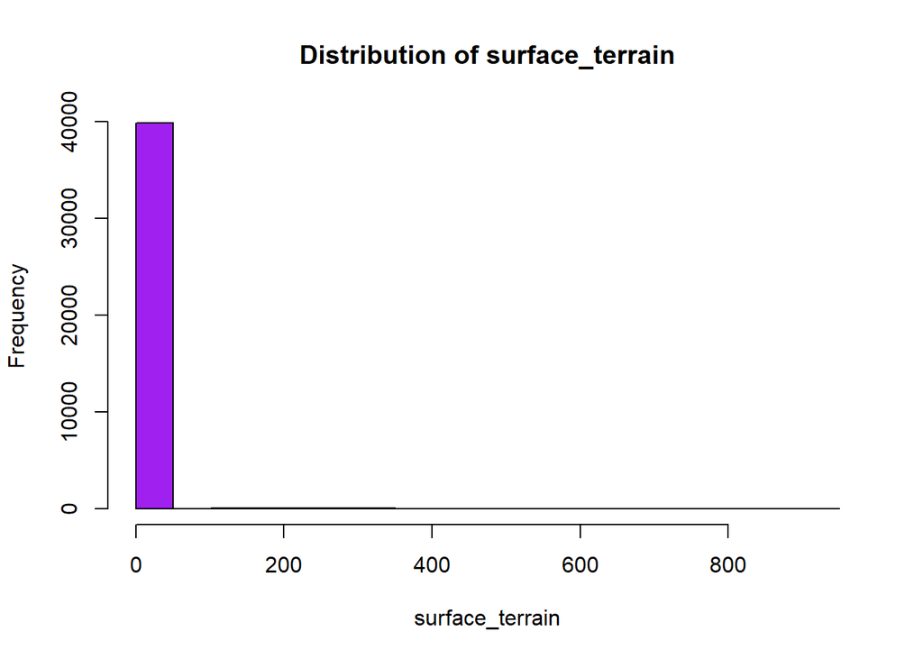

```r
hist(a$surface_terrain , col = "purple" , main="Distribution of surface_terrain" , xlab = "surface_terrain")
```

it seems strange!. lets see how many houses have a yard(e.g have non-zero surface_terrain area)

```r
t = a$surface_terrain
t[t>0] = 1
t = as.factor(t)
table(t)
```

```
## t
##     0     1
## 39825   548
```

so about 1.4% of the houses has a yard!!! let’s have look at distribution of non-zero ones :

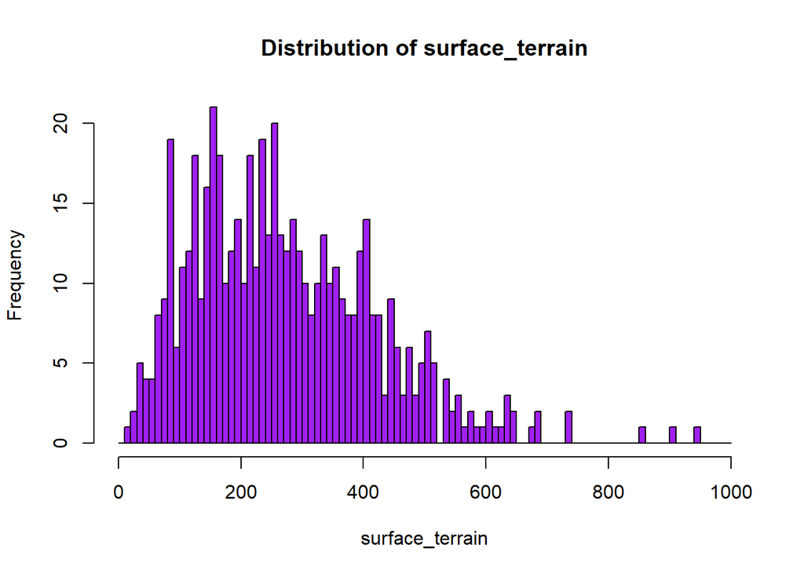

```r
t2 = a[a$surface_terrain!=0 , ]
hist(t2$surface_terrain , breaks = seq(0 , 1000 , 10) , col = "purple" , main="Distribution of surface_terrain" , xlab = "surface_terrain")
```

#### parkings_count:

it’s an integer value variable ranges from 0 to 3

```r
table(a$parkings_count)
```

```
##
##     0     1     2     3
## 18469 19817  1903   184
```

#### price:

it’s a float value variable ranges from 24000.00 to 2780000.00.

if we draw histogram of houses with respect to their price :

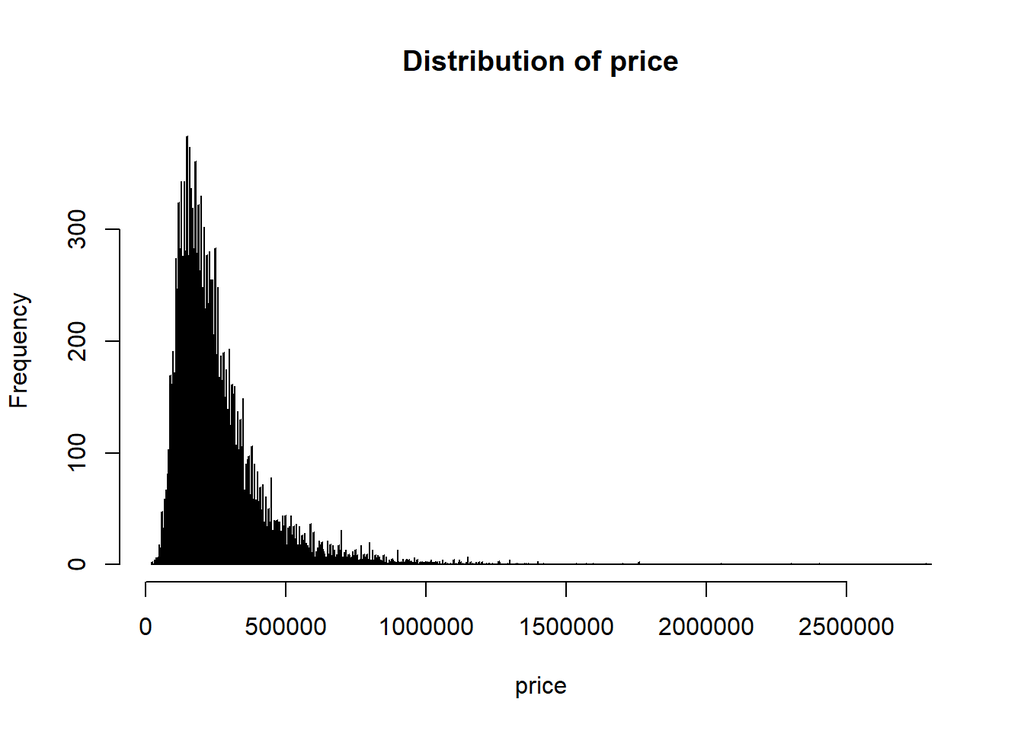

```r
hist(a$price , breaks = seq(20000 , 2800000 , 1000) ,  main="Distribution of price" , xlab = "price")
```

it seems it has a lot of outliers. if we count number of house with price greater the 1m :

```r
colSums(a[c("price")] > 1000000)
```

```
## price
##   176
```

so the number of outlier samples is small.(in relative to all samples). let’s see how these outlier affect the mean of price :

```r
m1 = mean(a$price , na.rm=TRUE)
m1
```

```
## [1] 255835.2
```

```r
b1 = a$price
b1 = b1[!is.na(b1) & b1 <= 1000000]
m2 = mean(b1)
m2
```

```
## [1] 251532.4
```

so the effect of outliers on mean of prices is about:

```r
m1 - m2
```

```
## [1] 4302.886
```

#### address:

it’s character value variable.

#### district:

it’s a 10-state factor variable showing districts of lyon. let’s see distribution of houses according to these districts:

```r
table(a$district)
```

```
##
## Lyon 1er Arrondissement  Lyon 2e Arrondissement  Lyon 3e Arrondissement
##                    1819                    1455                    5967
##  Lyon 4e Arrondissement  Lyon 5e Arrondissement  Lyon 6e Arrondissement
##                    2273                    2933                    2451
##  Lyon 7e Arrondissement  Lyon 8e Arrondissement  Lyon 9e Arrondissement
##                    5264                    4602                    3309
##            Villeurbanne
##                   10300
```

#### latitude, longitude:

float value variables showing location of the house.

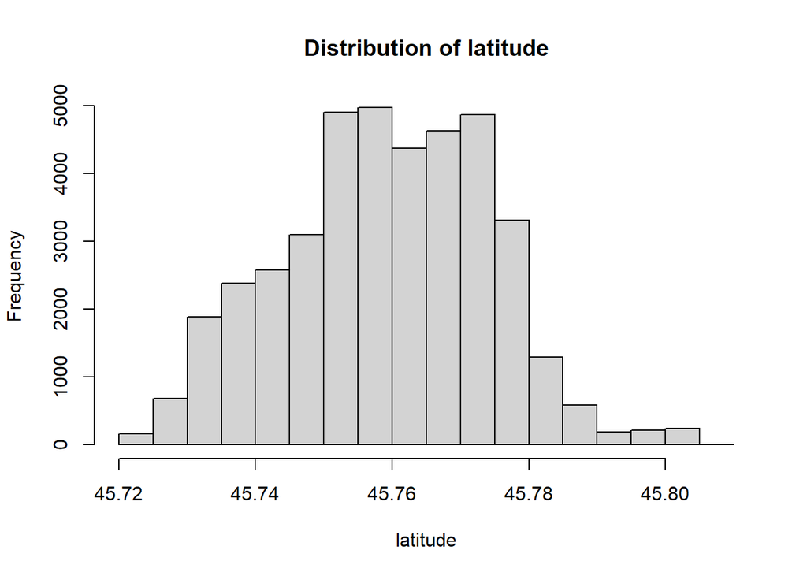

```r
hist(a$latitude ,  main="Distribution of latitude" , xlab = "latitude")
```

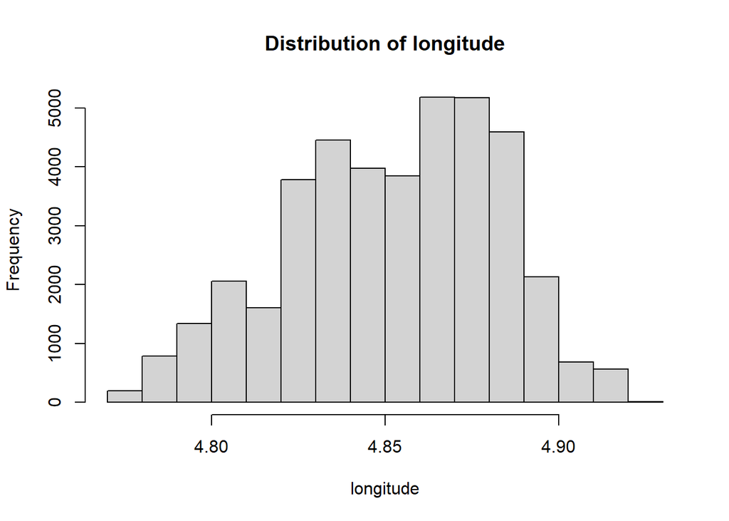

```r
hist(a$longitude, main="Distribution of longitude" , xlab = "longitude")
```

now let’s have a look at a map :

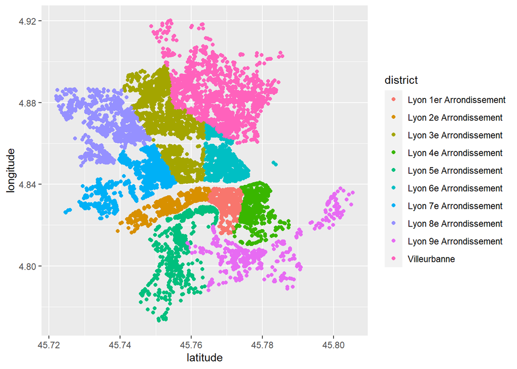

```r
a$district = as.factor(a$district)
ggplot(data = a)+geom_point(mapping = aes(x=latitude,y=longitude, color=district))
```

this plot will help us to have a better understanding of lyon’s districts.

another map :

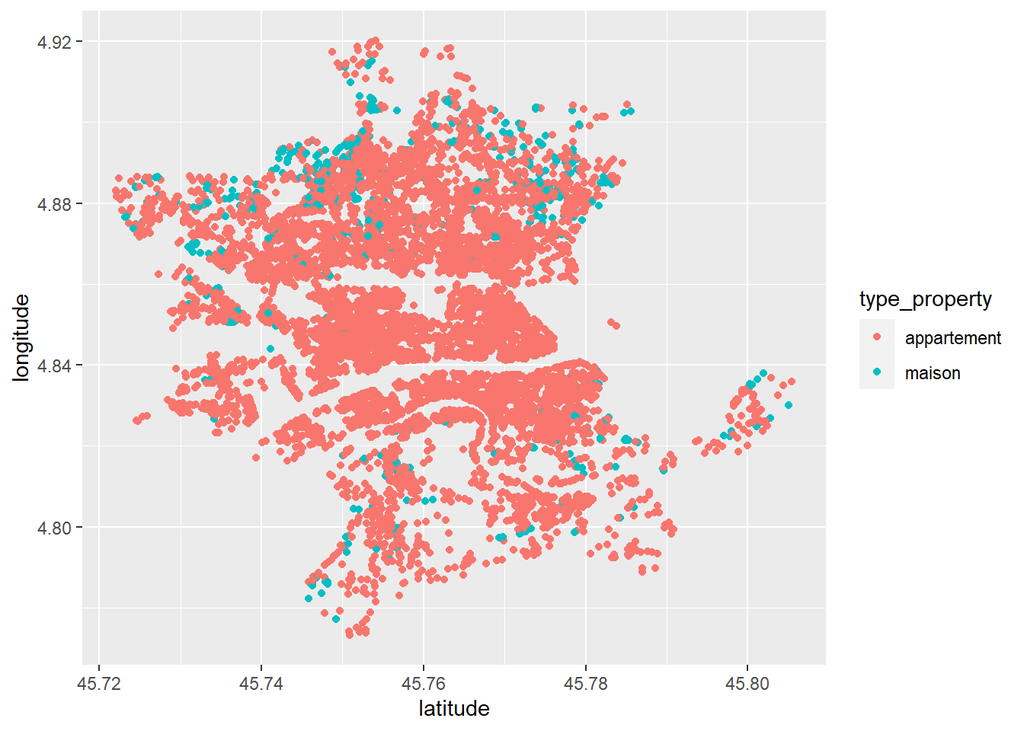

```r
a$type_property = as.factor(a$type_property)
ggplot(data = a)+geom_point(mapping = aes(x=latitude,y=longitude, color=type_property))
```

```r
a$type_property = as.character(a$type_property)
```

#### date_construction:

shows time of construction . by using construction_year which we have added to the dataset in the begining, we plot a histogram :

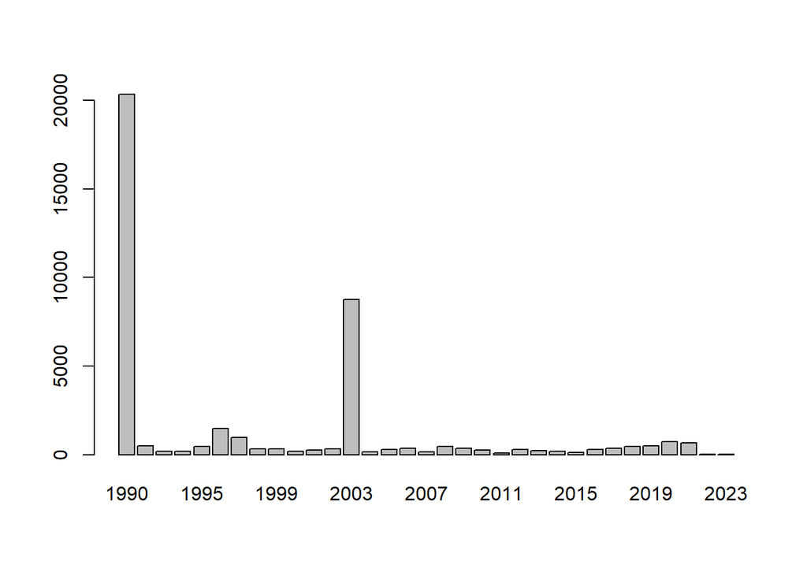

```r
a$cons_year = as.factor(a$cons_year)
barplot(table(a$cons_year))
```

wait what ?! constuction date of some the house is for future :| (year 2022 and 2023!) let’s count them!

```r
table(a$cons_year)
```

```
##
##  1990  1992  1993  1994  1995  1996  1997  1998  1999  2000  2001  2002  2003
## 20337   495   178   205   457  1475   982   336   318   205   245   332  8772
##  2004  2005  2006  2007  2008  2009  2010  2011  2012  2013  2014  2015  2016
##   146   289   370   147   463   376   271   105   294   222   194   110   295
##  2017  2018  2019  2020  2021  2022  2023
##   354   453   509   742   677    13     6
```

maybe some of these values are invalid dates (e.g construction date later than 2021/06/30 and they are not “VEFA” ):

```r
a$cons_year = as.character(a$cons_year)
a$cons_year = as.numeric(a$cons_year)
a$cons_month = as.numeric(a$cons_month)
colSums(a[c("cons_year")] == 2021 & a[c("cons_month")] >7 & a[c("type_purchase")]=="ancien")
```

```
## cons_year
##        55
```

```r
a$cons_year = as.character(a$cons_year)
a$cons_month = as.character(a$cons_month)
```

it seems that these dates are wrong and invalid.(55 invalid dates) so we should be aware of this in later calculations.

another map:

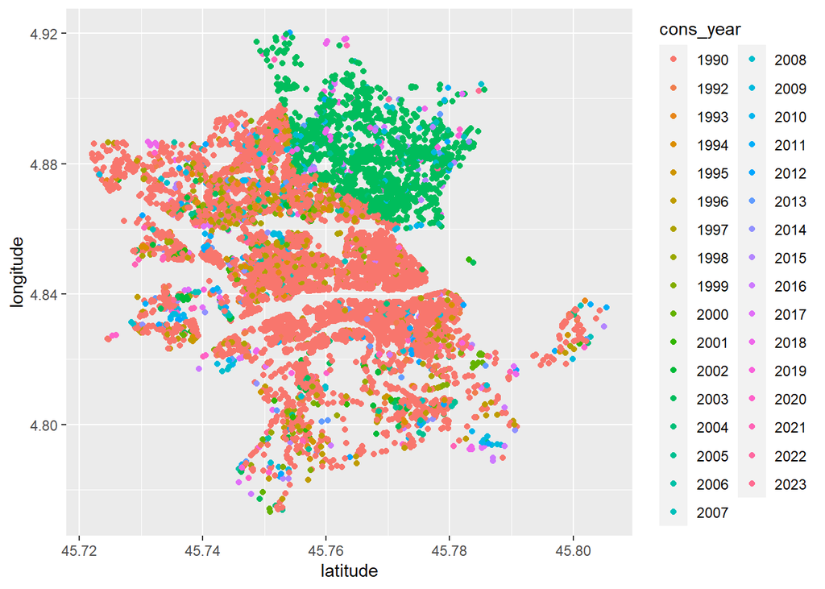

```r
ggplot(data = a)+geom_point(mapping = aes(x=latitude,y=longitude, color=cons_year))
```

it seems that the city can be divided in two parts of old-built and new-built houses.

## other useful data:

let’s have a look at number of transaction per district :

```r
a$year = as.factor(a$year)
table(a$district)
```

```
##
## Lyon 1er Arrondissement  Lyon 2e Arrondissement  Lyon 3e Arrondissement
##                    1819                    1455                    5967
##  Lyon 4e Arrondissement  Lyon 5e Arrondissement  Lyon 6e Arrondissement
##                    2273                    2933                    2451
##  Lyon 7e Arrondissement  Lyon 8e Arrondissement  Lyon 9e Arrondissement
##                    5264                    4602                    3309
##            Villeurbanne
##                   10300
```

the highest number of houses sold in these areas belongs to Villeurbanne.the lowest number of houses belongs to Lyon 2e Arrondissement.

let’s have a look at number of transaction per year :

```r
table(a$year)
```

```
##
##  2016  2017  2018  2019  2020  2021
##  4323 10004  8668  8480  6560  2338
```

as you can see, most of transactions take place in 2017 and year 2021 has the least transaction count.(we should notice that our data for years 2016 and 2021 covers only 6 month of each year, but for other years, all 12 months are covered.)

let’s have a look at number of transaction per year & transaction. :

```r
table(a$district , a$year)
```

```
##
##                           2016 2017 2018 2019 2020 2021
##   Lyon 1er Arrondissement  207  364  376  379  324  169
##   Lyon 2e Arrondissement   139  308  316  308  257  127
##   Lyon 3e Arrondissement   701 1437 1277 1300  981  271
##   Lyon 4e Arrondissement   255  496  478  463  368  213
##   Lyon 5e Arrondissement   304  649  596  616  509  259
##   Lyon 6e Arrondissement   271  618  509  525  432   96
##   Lyon 7e Arrondissement   530 1541 1109 1015  833  236
##   Lyon 8e Arrondissement   476 1150  964 1058  759  195
##   Lyon 9e Arrondissement   341  845  698  578  559  288
##   Villeurbanne            1099 2596 2345 2238 1538  484
```

```r
a$year = as.character(a$year)
```

let’s calculate mean of transaction price of each district according to different years :

```r
districts = c("Lyon 1er Arrondissement" , "Lyon 2e Arrondissement" ,
              "Lyon 3e Arrondissement" , "Lyon 4e Arrondissement" ,
              "Lyon 5e Arrondissement" , "Lyon 6e Arrondissement" ,
              "Lyon 7e Arrondissement" , "Lyon 8e Arrondissement" ,
              "Lyon 9e Arrondissement" , "Villeurbanne")

years = c("2016" , "2017" , "2018" , "2019" , "2020" , "2021")

means = c()
for (di in districts) {
  for (ye in years) {
    t = mean(a[a$year==ye & a$district ==di , 'price'])
    means = c(means , t)
  }
}
values = matrix(means,ncol=6,byrow=TRUE)
colnames(values) = years
rownames(values) = districts
values2 = as.table(values)
values2
```

```
##                             2016     2017     2018     2019     2020     2021
## Lyon 1er Arrondissement 225877.4 265992.5 288503.2 299805.8 325851.0 353713.4
## Lyon 2e Arrondissement  317490.5 332741.0 342569.1 352433.4 404312.3 441675.2
## Lyon 3e Arrondissement  228672.7 249749.3 261909.2 285424.3 325183.4 331594.5
## Lyon 4e Arrondissement  288027.1 291769.1 336038.3 341462.4 376105.6 385561.6
## Lyon 5e Arrondissement  217642.8 220424.0 235226.7 265356.3 276495.0 313640.2
## Lyon 6e Arrondissement  315191.3 352807.1 377342.8 429051.5 477132.3 437025.5
## Lyon 7e Arrondissement  215725.7 221528.5 252887.9 255762.4 289486.5 298194.6
## Lyon 8e Arrondissement  201843.3 216554.8 214956.6 231639.2 261233.3 283050.1
## Lyon 9e Arrondissement  198912.6 200852.1 208967.5 228671.7 246026.1 249811.5
## Villeurbanne            182992.7 189838.4 201563.2 207882.8 228655.2 233448.8
```

it seems that district “Villeurbanne” has the lowest prices(actually mean of prices) and district “Lyon 6e Arrondissement” has the highest prices.

now if we plot this table, we can see increase and decreases in price in another format :

```r
values = data.frame(values)
colnames(values) = years
rownames(values) = districts
values = transpose(values)
values = data.frame(years , values)

colnames(values) = c("years" , districts)
rownames(values) = years



df2 = data.frame(district=rep(districts, each=6),
                year=rep(years , times = 10) , price =means)


ggplot(df2, aes(x=year, y=price, group=district)) +
  geom_line(aes(color=district))+
  geom_point(aes(color=district))
```

[output not shown]

let’s calculate differences and Relative differences of prices for each district from year 2016 to 2021 and see which districts has minimum or maximum (relative) differences :

```r
xcv = c()
xcv2 = c()
for (di in districts) {
  a1 = df2[df2$district==di & df2$year=="2016" , 'price']
  a2 = df2[df2$district==di & df2$year=="2021" , 'price']
  percent = (a2-a1)/ a1
  percent2 = (a2-a1)/ 5
  xcv = c(xcv , percent)
  xcv2 = c(xcv2 , percent2)
}
```

Differences:

```r
names(xcv2) = districts
xcv2
```

```
## Lyon 1er Arrondissement  Lyon 2e Arrondissement  Lyon 3e Arrondissement
##                25567.19                24836.93                20584.36
##  Lyon 4e Arrondissement  Lyon 5e Arrondissement  Lyon 6e Arrondissement
##                19506.89                19199.48                24366.84
##  Lyon 7e Arrondissement  Lyon 8e Arrondissement  Lyon 9e Arrondissement
##                16493.78                16241.36                10179.79
##            Villeurbanne
##                10091.22
```

```r
B1 = which.min(xcv)
B2 = which.max(xcv)
print(paste("minimum increase in prices is:" ,xcv2[B1], " and is for district:" , names(which.min(xcv2)) ))
```

[output not shown]

```r
print(paste("maximum increase in prices is:" ,xcv2[B2], " and is for district:" , names(which.max(xcv2)) ))
```

```
## [1] "maximum increase in prices is: 25567.1946536318  and is for district: Lyon 1er Arrondissement"
```

Relative differences :

```r
names(xcv) = districts
xcv
```

```
## Lyon 1er Arrondissement  Lyon 2e Arrondissement  Lyon 3e Arrondissement
##               0.5659529               0.3911445               0.4500835
##  Lyon 4e Arrondissement  Lyon 5e Arrondissement  Lyon 6e Arrondissement
##               0.3386295               0.4410778               0.3865404
##  Lyon 7e Arrondissement  Lyon 8e Arrondissement  Lyon 9e Arrondissement
##               0.3822859               0.4023259               0.2558860
##            Villeurbanne
##               0.2757275
```

```r
A1 = which.min(xcv)
A2 = which.max(xcv)
print(paste("minimum increase rate is:" ,xcv[A1], " and is for district:" , names(which.min(xcv)) ))
```

```
## [1] "minimum increase rate is: 0.255885989837953  and is for district: Lyon 9e Arrondissement"
```

```r
print(paste("maximum increase rate is:" ,xcv[A2], " and is for district:" , names(which.max(xcv)) ))
```

```
## [1] "maximum increase rate is: 0.565952900375088  and is for district: Lyon 1er Arrondissement"
```

in this figure , we set 2016/1 (jan) to be 1 and for each month of each yaer we calculate time = 12*(year-2016) + month. then calculate mean of prices of that time. and then plot.

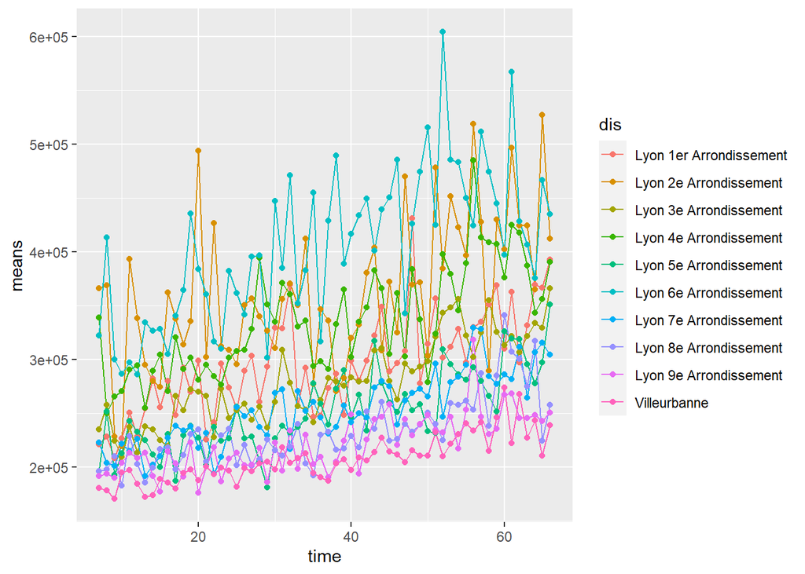

```r
districts = c("Lyon 1er Arrondissement" , "Lyon 2e Arrondissement" ,
              "Lyon 3e Arrondissement" , "Lyon 4e Arrondissement" ,
              "Lyon 5e Arrondissement" , "Lyon 6e Arrondissement" ,
              "Lyon 7e Arrondissement" , "Lyon 8e Arrondissement" ,
              "Lyon 9e Arrondissement" , "Villeurbanne")

years = c("2016" , "2017" , "2018" , "2019" , "2020" , "2021")
month = c("01" ,"02","03","04","05","06","07","08","09","10","11","12")

means = c()
dis = c()
yearss = c()
months = c()
for (di in districts) {
  for (ye in years) {
    for (mo in month) {
      t = mean(a[a$year==ye & a$month==mo & a$district ==di , 'price'])
      means = c(means , t)
      dis = append(dis , di)
      yearss = append(yearss , ye)
      months = append(months , mo)
    }

  }
}
yearss = as.numeric(yearss)
yearss = yearss - 2016
months = as.numeric(months)

time = 12 * yearss + months

nbv = data.frame(means , dis , yearss , months , time , stringsAsFactors = F)
nbv2 = nbv[complete.cases(nbv) , ]


ggplot(nbv2, aes(x=time, y=means, group=dis)) +
  geom_line(aes(color=dis))+
  geom_point(aes(color=dis))
```

this plot has much more information but it is really ugly. the best thing we can do is to plot seperatly for each district(which we are not going to do.)

__________________________________________________________________________________________________”

now, as we promised, if we plot a map of houses according to their location with respect to their year of transaction :

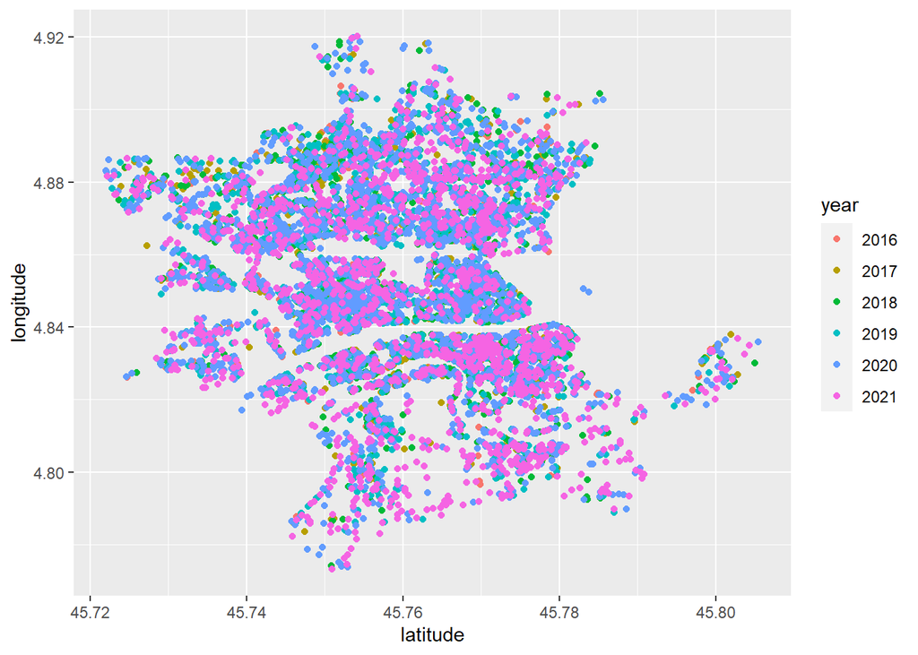

```r
a$year = as.factor(a$year)
ggplot(data = a)+geom_point(mapping = aes(x=latitude,y=longitude, color=year))
```

```r
a$year = as.character(a$year)
```

## FIND RELATION BETWEEN COLUMNS

let’s plot a heatmap which shows the correlations between columns of the dataset. we just use numerical columns :

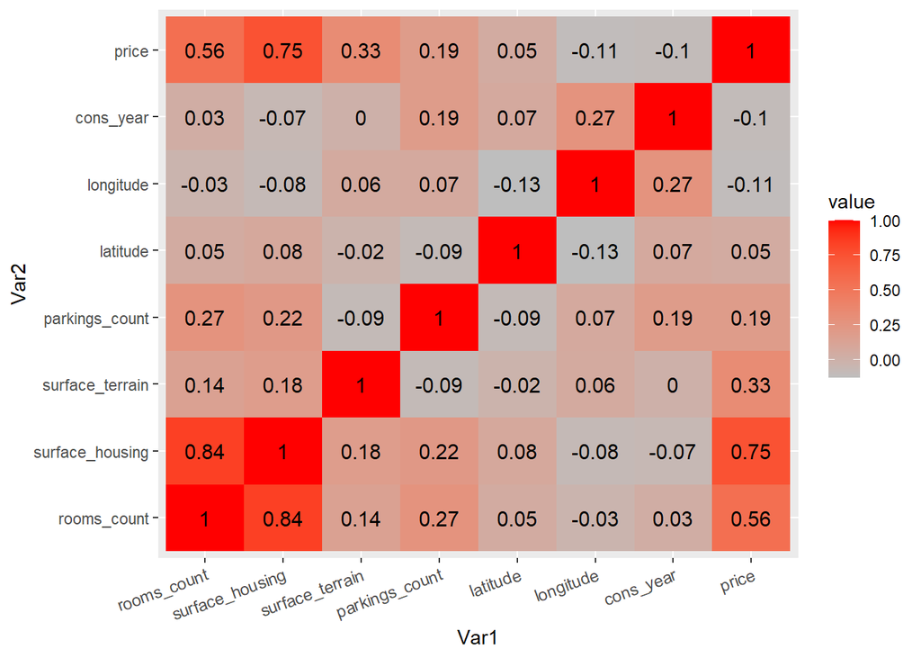

```r
new_a = a[c(4,5,6,7 ,11,12,17, 8)]
new_a$cons_year = as.numeric(new_a$cons_year)

corr = round(cor(new_a),2)

mcorr = melt(corr , na.rm = TRUE)

ggplot(data = mcorr, aes(x=Var1, y=Var2,fill=value)) +
geom_tile() +
   scale_fill_gradient(low = "gray", high = "red") +
  geom_text(aes(Var2, Var1, label = value),
          color = "black", size = 4) +theme(axis.text.x = element_text(angle = 20, vjust = 1,
    size = 9, hjust = 1))
```

now let’s investigate this heatmap.

1- it seems that “rooms_count” and “surface_housing” are positively correlated (0.84). it seems logical: as number of rooms grow, total area covered by the house will increase.

2- another noticeable correlation, is between “price” and “surface_housing”. it is also reasonable to think that the vaster a house is, the more expensive it becomes.

3- another noticeable correlation, is between “price” and “rooms_count”. with conclusions above, it’s reasonable to think with more rooms, there will be more area covered by the house , and the vaster it is, the more expensive it becomes. but this correlation is less noticeable than two above.

let’s plot some scatters to see :

1-

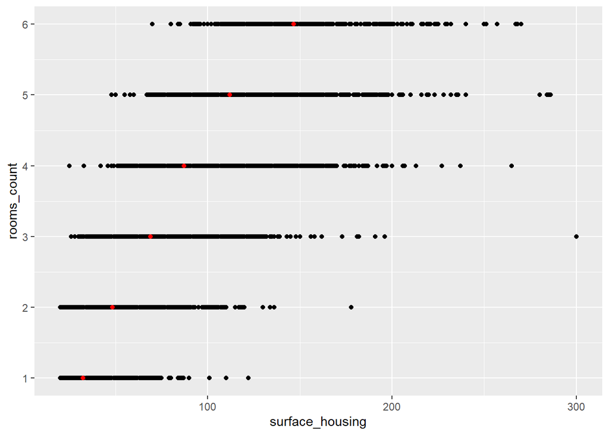

```r
r1 = (a[c("rooms_count")]==1)
r2 = (a[c("rooms_count")]==2)
r3 = (a[c("rooms_count")]==3)
r4 = (a[c("rooms_count")]==4)
r5 = (a[c("rooms_count")]==5)
r6 = (a[c("rooms_count")]==6)

ggplot() + geom_point(mapping = aes(a$surface_housing , a$rooms_count))+
    scale_y_continuous(breaks = c(0,1,2,3,4,5,6)) +
  geom_point(mapping = aes(mean(a$surface_housing[r1]) , 1) , color="red")+
  geom_point(mapping = aes(mean(a$surface_housing[r2]) , 2) , color="red")+
  geom_point(mapping = aes(mean(a$surface_housing[r3]) , 3) , color="red")+
  geom_point(mapping = aes(mean(a$surface_housing[r4]) , 4) , color="red")+
  geom_point(mapping = aes(mean(a$surface_housing[r5]) , 5) , color="red")+
  geom_point(mapping = aes(mean(a$surface_housing[r6]) , 6) , color="red")+ xlab("surface_housing") + ylab("rooms_count")
```

now we can see the correlation better. the red dots are mean of surface_housing in each row. so we can see that when number of rooms increases, surface_housing increase too.

2-

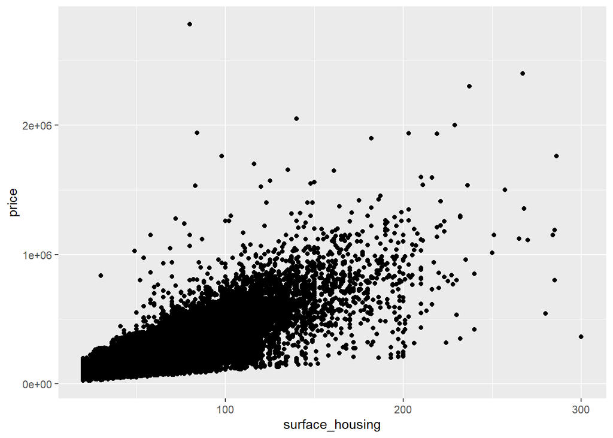

```r
ggplot() + geom_point(mapping = aes(a$surface_housing , a$price))+xlab("surface_housing")+ylab("price")
```

it seems that the price of a house grows as surface of the house grows.(in total, some outliers may not behave like this.)

3-

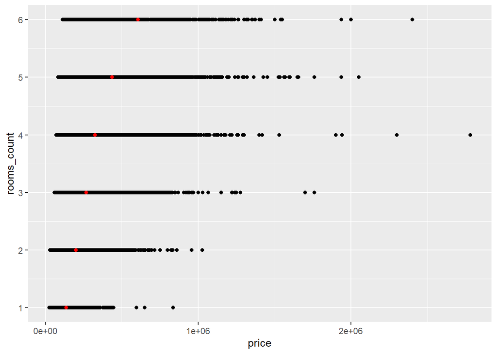

```r
r1 = (a[c("rooms_count")]==1)
r2 = (a[c("rooms_count")]==2)
r3 = (a[c("rooms_count")]==3)
r4 = (a[c("rooms_count")]==4)
r5 = (a[c("rooms_count")]==5)
r6 = (a[c("rooms_count")]==6)


ggplot() + geom_point(mapping = aes(a$price , a$rooms_count)) +
  scale_y_continuous(breaks = c(0,1,2,3,4,5,6))+ geom_point(mapping = aes(mean(a$price[r1]) , 1) , color="red")+ geom_point(mapping = aes(mean(a$price[r2]) , 2) , color="red")+ geom_point(mapping = aes(mean(a$price[r3]) , 3) , color="red")+ geom_point(mapping = aes(mean(a$price[r4]) , 4) , color="red")+
geom_point(mapping = aes(mean(a$price[r5]) , 5) , color="red")+
geom_point(mapping = aes(mean(a$price[r6]) , 6) , color="red")+xlab("price") +ylab("rooms_count")
```

now we can see the correlation better. the red dots are mean of price in each row. so we can see that when number of rooms of a house increases, price of the house increase too.(but it is less obvious than the increament in surface_housing).

#### we will do some regression tests in part ii to prove these assumptions.

## ADD EXTRA COLUMNS :

we have added some columns in the beginning of our work. here we add another column :

let’s see how much does 1m^2 area cost(e.g land price) for each house?

```r
a$area_price_ratio = a$price / a$surface_housing
```

maximum ratio is :

```r
max(a$area_price_ratio)
```

```
## [1] 34750
```

minimum ratio is:

```r
min(a$area_price_ratio)
```

```
## [1] 1000
```

mean of all ratios is :

```r
mean(a$area_price_ratio)
```

```
## [1] 3965.774
```

let’s plot map of all houses again. this time color of each point will reflect the area_price_ratio

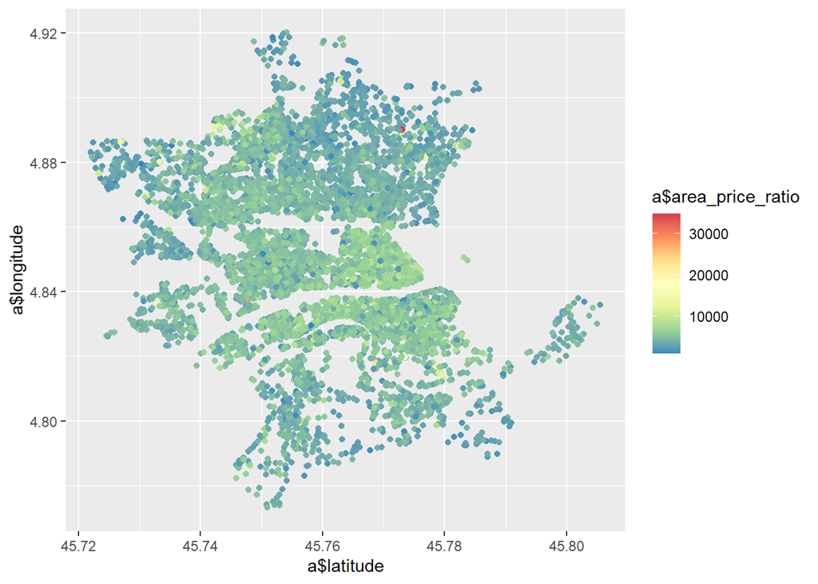

```r
ggplot()+geom_point(mapping = aes(x=a$latitude,y=a$longitude , color = a$area_price_ratio) )+scale_color_distiller(palette = 'Spectral')
```

let’s see its histogram :

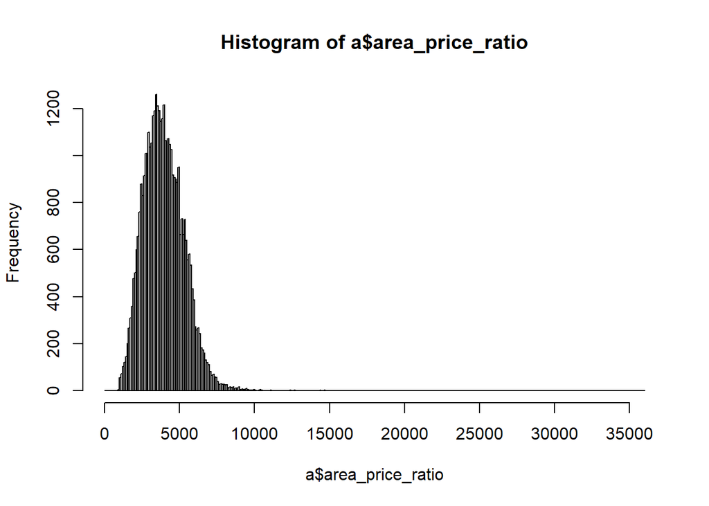

```r
hist(a$area_price_ratio , breaks = seq(0 , 36000 , 100))
```

it looks like a normal curve.but, it seems that we have a lot of outliers.

lets see how many house have a ratio greater than 10000 :

```r
colSums(a[c("area_price_ratio")] > 10000)
```

```
## area_price_ratio
##               50
```

so the number of outlier samples is small.(in relative to all samples). let’s see how these outlier affect the mean of price :

```r
m1 = mean(a$area_price_ratio , na.rm=TRUE)
m1
```

```
## [1] 3965.774
```

```r
b1 = a$area_price_ratio
b1 = b1[!is.na(b1) & b1 <= 10000]
m2 = mean(b1)
m2
```

```
## [1] 3953.48
```

so the effect of outliers on mean of prices is about:

```r
m1 - m2
```

```
## [1] 12.29448
```

so it seems that those outliers does not have strong effect on the land price.

in the end let’s plot another figure : this figure will show how “area_price_ratio” changed during time for each district.

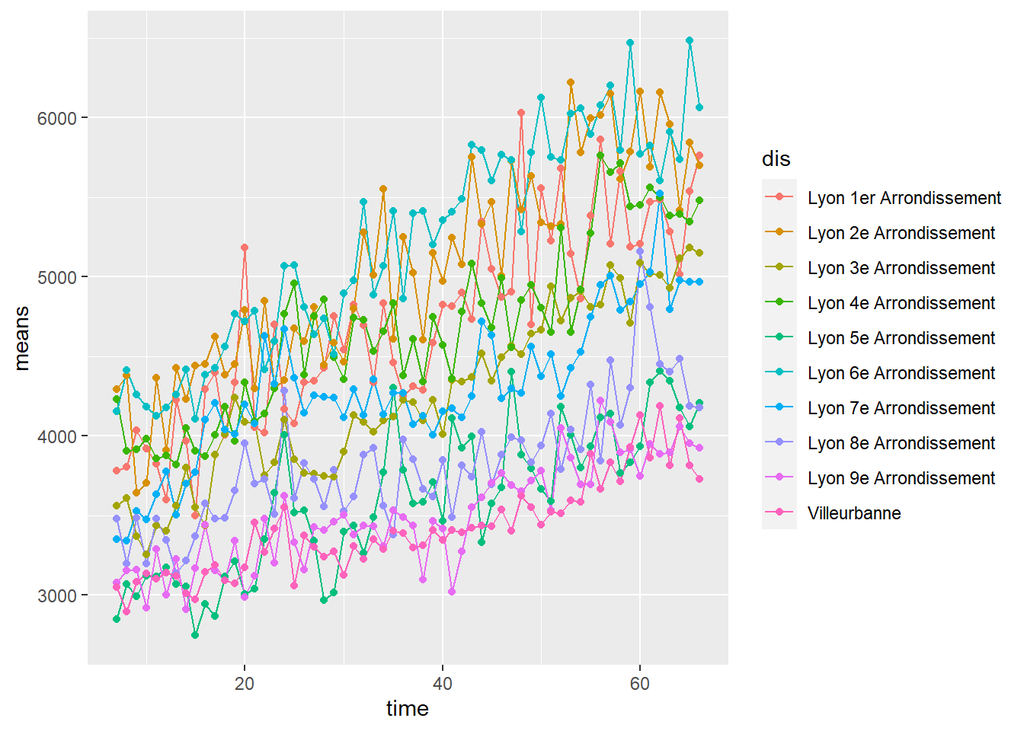

```r
districts = c("Lyon 1er Arrondissement" , "Lyon 2e Arrondissement" ,
              "Lyon 3e Arrondissement" , "Lyon 4e Arrondissement" ,
              "Lyon 5e Arrondissement" , "Lyon 6e Arrondissement" ,
              "Lyon 7e Arrondissement" , "Lyon 8e Arrondissement" ,
              "Lyon 9e Arrondissement" , "Villeurbanne")

years = c("2016" , "2017" , "2018" , "2019" , "2020" , "2021")
month = c("01" ,"02","03","04","05","06","07","08","09","10","11","12")

means = c()
dis = c()
yearss = c()
months = c()
for (di in districts) {
  for (ye in years) {
    for (mo in month) {
      t = mean(a[a$year==ye & a$month==mo & a$district ==di , 'area_price_ratio'])
      means = c(means , t)
      dis = append(dis , di)
      yearss = append(yearss , ye)
      months = append(months , mo)
    }

  }
}
yearss = as.numeric(yearss)
yearss = yearss - 2016
months = as.numeric(months)

time = 12 * yearss + months

nbv = data.frame(means , dis , yearss , months , time , stringsAsFactors = F)

nbv2 = nbv[complete.cases(nbv) , ]



ggplot(nbv2, aes(x=time, y=means, group=dis)) +
  geom_line(aes(color=dis))+
  geom_point(aes(color=dis))
```

in this figure , we set 2016/1 (jan) to be 1 and for each month of each yaer we calculate time = 12*(year-2016) + month. then calculate mean of (area_price_ratio) of that time for each district. and then plot.

we use this figure in the next part.

# part ii

### 1

the first and most important thing we can do, is to do a regression for price according to other features. this regression can be used for estimating price for other houses :

```r
a$cons_year = as.numeric(a$cons_year)
fit3 = lm(price~rooms_count + surface_housing + surface_terrain + parkings_count + cons_year + station_distance  , data=a)
summary(fit3)
```

```
##
## Call:
## lm(formula = price ~ rooms_count + surface_housing + surface_terrain +
##     parkings_count + cons_year + station_distance, data = a)
##
## Residuals:
##      Min       1Q   Median       3Q      Max
## -1010716   -51771    -5013    46951  1914036
##
## Coefficients:
##                    Estimate Std. Error t value Pr(>|t|)
## (Intercept)      1399583.48  106718.22   13.12   <2e-16 ***
## rooms_count       -28551.83     745.58  -38.30   <2e-16 ***
## surface_housing     4795.49      31.05  154.42   <2e-16 ***
## surface_terrain      936.72      13.20   70.97   <2e-16 ***
## parkings_count     23900.86     827.29   28.89   <2e-16 ***
## cons_year           -689.61      53.44  -12.90   <2e-16 ***
## station_distance  -36031.42    1119.32  -32.19   <2e-16 ***
## ---
## Signif. codes:  0 '***' 0.001 '**' 0.01 '*' 0.05 '.' 0.1 ' ' 1
##
## Residual standard error: 93600 on 40366 degrees of freedom
## Multiple R-squared:  0.6331, Adjusted R-squared:  0.633
## F-statistic: 1.161e+04 on 6 and 40366 DF,  p-value: < 2.2e-16
```

```r
a$cons_year = as.character(a$cons_year)
```

the residual error of this regression is 93600.let’s use type_property as a dummy variable :

```r
a$cons_year = as.numeric(a$cons_year)
# a2 = a[(a$price < 750000) & (a$type_property=="appartement") ,]
a2 = a
a2$type_property =as.factor(a2$type_property)

fit3 = lm(price~rooms_count + surface_housing + surface_terrain + parkings_count + cons_year + station_distance + type_property , data=a2)
summary(fit3)
```

```
##
## Call:
## lm(formula = price ~ rooms_count + surface_housing + surface_terrain +
##     parkings_count + cons_year + station_distance + type_property,
##     data = a2)
##
## Residuals:
##      Min       1Q   Median       3Q      Max
## -1010967   -51752    -5024    46959  1909657
##
## Coefficients:
##                       Estimate Std. Error t value Pr(>|t|)
## (Intercept)         1396585.43  106757.16  13.082   <2e-16 ***
## rooms_count          -28530.42     745.87 -38.251   <2e-16 ***
## surface_housing        4796.28      31.06 154.401   <2e-16 ***
## surface_terrain         952.68      20.26  47.014   <2e-16 ***
## parkings_count        23836.91     829.58  28.734   <2e-16 ***
## cons_year              -688.13      53.46 -12.872   <2e-16 ***
## station_distance     -36010.66    1119.49 -32.167   <2e-16 ***
## type_propertymaison   -5966.87    5745.91  -1.038    0.299
## ---
## Signif. codes:  0 '***' 0.001 '**' 0.01 '*' 0.05 '.' 0.1 ' ' 1
##
## Residual standard error: 93600 on 40365 degrees of freedom
## Multiple R-squared:  0.6331, Adjusted R-squared:  0.633
## F-statistic:  9949 on 7 and 40365 DF,  p-value: < 2.2e-16
```

```r
a$cons_year = as.character(a$cons_year)
```

nothing changed! let’s use districts as dummy variables :

```r
a$cons_year = as.numeric(a$cons_year)
# a2 = a[(a$price < 750000) & (a$type_property=="appartement") ,]
a2 = a
a2$type_property =as.factor(a2$type_property)
a2$district = as.factor(a2$district)
fit3 = lm(price~rooms_count + surface_housing + surface_terrain + parkings_count + cons_year + station_distance + type_property + district , data=a2)
summary(fit3)
```

```
##
## Call:
## lm(formula = price ~ rooms_count + surface_housing + surface_terrain +
##     parkings_count + cons_year + station_distance + type_property +
##     district, data = a2)
##
## Residuals:
##     Min      1Q  Median      3Q     Max
## -892129  -45232   -1672   42893 1909310
##
## Coefficients:
##                                  Estimate Std. Error t value Pr(>|t|)
## (Intercept)                    -2.171e+06  1.122e+05 -19.346   <2e-16 ***
## rooms_count                    -1.699e+04  6.921e+02 -24.543   <2e-16 ***
## surface_housing                 4.147e+03  2.931e+01 141.494   <2e-16 ***
## surface_terrain                 9.915e+02  1.844e+01  53.775   <2e-16 ***
## parkings_count                  3.397e+04  7.811e+02  43.494   <2e-16 ***
## cons_year                       1.125e+03  5.633e+01  19.973   <2e-16 ***
## station_distance               -3.246e+04  1.380e+03 -23.523   <2e-16 ***
## type_propertymaison             1.256e+04  5.233e+03   2.400   0.0164 *
## districtLyon 2e Arrondissement  2.904e+04  3.006e+03   9.662   <2e-16 ***
## districtLyon 3e Arrondissement -4.162e+04  2.326e+03 -17.896   <2e-16 ***
## districtLyon 4e Arrondissement  6.842e+03  2.703e+03   2.532   0.0114 *
## districtLyon 5e Arrondissement -4.791e+04  2.909e+03 -16.470   <2e-16 ***
## districtLyon 6e Arrondissement  5.210e+04  2.646e+03  19.691   <2e-16 ***
## districtLyon 7e Arrondissement -4.432e+04  2.381e+03 -18.615   <2e-16 ***
## districtLyon 8e Arrondissement -7.568e+04  2.439e+03 -31.031   <2e-16 ***
## districtLyon 9e Arrondissement -7.536e+04  2.594e+03 -29.046   <2e-16 ***
## districtVilleurbanne           -1.037e+05  2.331e+03 -44.476   <2e-16 ***
## ---
## Signif. codes:  0 '***' 0.001 '**' 0.01 '*' 0.05 '.' 0.1 ' ' 1
##
## Residual standard error: 85100 on 40356 degrees of freedom
## Multiple R-squared:  0.6967, Adjusted R-squared:  0.6966
## F-statistic:  5794 on 16 and 40356 DF,  p-value: < 2.2e-16
```

```r
a$cons_year = as.character(a$cons_year)
```

it got really better!(residual error is now 85100). but i think it can get even better. remember that we have some outliers with really high prices.let us not use them :

```r
a$cons_year = as.numeric(a$cons_year)
a2 = a[(a$price < 750000),]
a2$type_property =as.factor(a2$type_property)
a2$district = as.factor(a2$district)
fit3 = lm(price~rooms_count + surface_housing + surface_terrain + parkings_count + cons_year + station_distance + type_property + district , data=a2)
summary(fit3)
```

```
##
## Call:
## lm(formula = price ~ rooms_count + surface_housing + surface_terrain +
##     parkings_count + cons_year + station_distance + type_property +
##     district, data = a2)
##
## Residuals:
##     Min      1Q  Median      3Q     Max
## -711554  -43321   -2468   41682  424908
##
## Coefficients:
##                                  Estimate Std. Error t value Pr(>|t|)
## (Intercept)                    -2.077e+06  9.786e+04 -21.222  < 2e-16 ***
## rooms_count                    -7.070e+03  6.339e+02 -11.153  < 2e-16 ***
## surface_housing                 3.381e+03  2.843e+01 118.888  < 2e-16 ***
## surface_terrain                 6.211e+02  2.275e+01  27.304  < 2e-16 ***
## parkings_count                  3.259e+04  6.889e+02  47.312  < 2e-16 ***
## cons_year                       1.088e+03  4.912e+01  22.142  < 2e-16 ***
## station_distance               -3.215e+04  1.206e+03 -26.661  < 2e-16 ***
## type_propertymaison             3.959e+04  5.108e+03   7.750 9.44e-15 ***
## districtLyon 2e Arrondissement  1.613e+04  2.669e+03   6.044 1.52e-09 ***
## districtLyon 3e Arrondissement -3.935e+04  2.036e+03 -19.325  < 2e-16 ***
## districtLyon 4e Arrondissement  4.231e+03  2.374e+03   1.782   0.0748 .
## districtLyon 5e Arrondissement -4.691e+04  2.548e+03 -18.409  < 2e-16 ***
## districtLyon 6e Arrondissement  3.853e+04  2.347e+03  16.418  < 2e-16 ***
## districtLyon 7e Arrondissement -4.388e+04  2.082e+03 -21.077  < 2e-16 ***
## districtLyon 8e Arrondissement -7.475e+04  2.134e+03 -35.037  < 2e-16 ***
## districtLyon 9e Arrondissement -7.327e+04  2.266e+03 -32.329  < 2e-16 ***
## districtVilleurbanne           -1.026e+05  2.039e+03 -50.300  < 2e-16 ***
## ---
## Signif. codes:  0 '***' 0.001 '**' 0.01 '*' 0.05 '.' 0.1 ' ' 1
##
## Residual standard error: 73790 on 39705 degrees of freedom
## Multiple R-squared:  0.6451, Adjusted R-squared:  0.645
## F-statistic:  4511 on 16 and 39705 DF,  p-value: < 2.2e-16
```

```r
a$cons_year = as.character(a$cons_year)
```

again it got really better!(residual error is now 73790). but i think it can get even better. remember that we have some outliers with really high prices.let us not use them.also use rooms_count and parking_count as dummy variables :

```r
a$cons_year = as.numeric(a$cons_year)
a2 = a[(a$price < 750000),]
a2$type_property =as.factor(a2$type_property)
a2$district = as.factor(a2$district)
a2$parkings_count = as.factor(a2$parkings_count)
a2$rooms_count = as.factor(a2$rooms_count)
fit3 = lm(price~rooms_count + surface_housing + surface_terrain + parkings_count + cons_year + station_distance + type_property + district , data=a2)
summary(fit3)
```

```
##
## Call:
## lm(formula = price ~ rooms_count + surface_housing + surface_terrain +
##     parkings_count + cons_year + station_distance + type_property +
##     district, data = a2)
##
## Residuals:
##     Min      1Q  Median      3Q     Max
## -725034  -43792   -1843   41454  422678
##
## Coefficients:
##                                  Estimate Std. Error t value Pr(>|t|)
## (Intercept)                    -1.951e+06  9.803e+04 -19.900  < 2e-16 ***
## rooms_count2                   -2.011e+03  1.283e+03  -1.567 0.117056
## rooms_count3                   -5.337e+03  1.584e+03  -3.369 0.000756 ***
## rooms_count4                   -1.717e+04  2.024e+03  -8.481  < 2e-16 ***
## rooms_count5                   -2.773e+04  2.822e+03  -9.828  < 2e-16 ***
## rooms_count6                   -7.911e+04  4.786e+03 -16.532  < 2e-16 ***
## surface_housing                 3.417e+03  2.850e+01 119.878  < 2e-16 ***
## surface_terrain                 6.298e+02  2.266e+01  27.790  < 2e-16 ***
## parkings_count1                 3.589e+04  8.464e+02  42.403  < 2e-16 ***
## parkings_count2                 5.662e+04  1.891e+03  29.945  < 2e-16 ***
## parkings_count3                 7.131e+04  5.862e+03  12.165  < 2e-16 ***
## cons_year                       1.018e+03  4.920e+01  20.685  < 2e-16 ***
## station_distance               -3.271e+04  1.202e+03 -27.208  < 2e-16 ***
## type_propertymaison             4.303e+04  5.091e+03   8.451  < 2e-16 ***
## districtLyon 2e Arrondissement  1.559e+04  2.659e+03   5.865 4.52e-09 ***
## districtLyon 3e Arrondissement -4.067e+04  2.034e+03 -19.999  < 2e-16 ***
## districtLyon 4e Arrondissement  3.463e+03  2.366e+03   1.464 0.143216
## districtLyon 5e Arrondissement -4.717e+04  2.539e+03 -18.576  < 2e-16 ***
## districtLyon 6e Arrondissement  3.770e+04  2.338e+03  16.125  < 2e-16 ***
## districtLyon 7e Arrondissement -4.517e+04  2.079e+03 -21.727  < 2e-16 ***
## districtLyon 8e Arrondissement -7.645e+04  2.133e+03 -35.839  < 2e-16 ***
## districtLyon 9e Arrondissement -7.451e+04  2.261e+03 -32.948  < 2e-16 ***
## districtVilleurbanne           -1.038e+05  2.036e+03 -50.955  < 2e-16 ***
## ---
## Signif. codes:  0 '***' 0.001 '**' 0.01 '*' 0.05 '.' 0.1 ' ' 1
##
## Residual standard error: 73490 on 39699 degrees of freedom
## Multiple R-squared:  0.6481, Adjusted R-squared:  0.6479
## F-statistic:  3323 on 22 and 39699 DF,  p-value: < 2.2e-16
```

```r
a$cons_year = as.character(a$cons_year)
```

### 2

remember this :

```r
names(xcv) = districts
xcv
```

```
## Lyon 1er Arrondissement  Lyon 2e Arrondissement  Lyon 3e Arrondissement
##               0.5659529               0.3911445               0.4500835
##  Lyon 4e Arrondissement  Lyon 5e Arrondissement  Lyon 6e Arrondissement
##               0.3386295               0.4410778               0.3865404
##  Lyon 7e Arrondissement  Lyon 8e Arrondissement  Lyon 9e Arrondissement
##               0.3822859               0.4023259               0.2558860
##            Villeurbanne
##               0.2757275
```

```r
A1 = which.min(xcv)
A2 = which.max(xcv)
print(paste("minimum increase rate is:" ,xcv[A1], " and is for district:" , names(which.min(xcv)) ))
```

```
## [1] "minimum increase rate is: 0.255885989837953  and is for district: Lyon 9e Arrondissement"
```

```r
print(paste("maximum increase rate is:" ,xcv[A2], " and is for district:" , names(which.max(xcv)) ))
```

```
## [1] "maximum increase rate is: 0.565952900375088  and is for district: Lyon 1er Arrondissement"
```

so it seems that in district “Lyon 1er Arrondissement” , mean of prices in year 2021 is almost 1.56 times mean of prices in year 2016.

so we run a hypothesis test:

H0 : mean of prices of year 2021 is 1.5 times mean of prices in year 2016.(in Lyon 1er Arrondissement)

H1 : otherwise.

```r
d1er = a[a$district=="Lyon 1er Arrondissement", ]
d1er2016 = d1er[d1er$year=="2016" ,]
d1er2021 = d1er[d1er$year=="2021", ]
```

```r
z.test(d1er2021$price, y = 1.5*d1er2016$price , alternative = 'two.sided', mu = 0, sigma.x = sd(d1er2021$price), sigma.y = sd(1.5*d1er2016$price),conf.level = 0.95)
```

```
##
##  Two-sample z-Test
##
## data:  d1er2021$price and 1.5 * d1er2016$price
## z = 0.7464, p-value = 0.4554
## alternative hypothesis: true difference in means is not equal to 0
## 95 percent confidence interval:
##  -24221.34  54015.88
## sample estimates:
## mean of x mean of y
##  353713.4  338816.1
```

we can run such a test for other districts and other years too.(of course with different multiplication rate)

### 3

let’s have look at mean price of apartments and maisons :

```r
r1 = a[a$type_property == "appartement" , ]
r2 = a[a$type_property == "maison" , ]

mean(r1$price)
```

```
## [1] 250217.8
```

```r
mean(r2$price)
```

```
## [1] 587203.3
```

obviously these two values can not be equal.(you can run a test and see p-value < 2.2e-16. )

but, we can a test to see how much is mean of maisons is greater than mean of apartements ?

if we divide this two value, the ratio is :

```r
mean(r2$price) / mean(r1$price)
```

```
## [1] 2.346768
```

so let’s run a test to see if mean price of maisons is 2.4 times greater than mean price of aprtments :

H0 : mean(maison) = 2.4 * mean(apartment)

H1 : otherwise.

```r
 z.test(r2$price, y = 2.4*r1$price , alternative = 'two.sided', mu = 0, sigma.x = sd(r2$price), sigma.y = sd(2.4*r1$price),conf.level = 0.95)
```

```
##
##  Two-sample z-Test
##
## data:  r2$price and 2.4 * r1$price
## z = -1.051, p-value = 0.2933
## alternative hypothesis: true difference in means is not equal to 0
## 95 percent confidence interval:
##  -38158.73  11519.68
## sample estimates:
## mean of x mean of y
##  587203.3  600522.8
```

notice that if we run the test with a multiple of 2.5(instead of 2.4) then the null hypothesis would be rejected.

### 4

we calculated distance of each house to its nearest station in part I . let’s use this feature. first let’s have a look at the distribution of this feature :

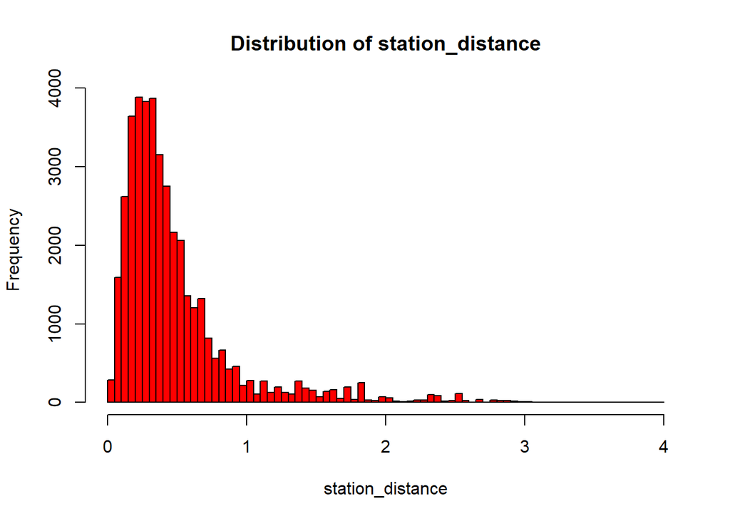

```r
hist(a$station_distance , breaks = seq(0 , 4 , 0.05),col = "red" , main="Distribution of station_distance" , xlab = "station_distance")
```

now let’s count number of houses for which the nearest station is located in a radius of at most 100 meters and number of houses for which the nearest station is located in a radius of at least 1450 meters:

```r
nrow(a[a$station_distance<0.1 , ])
```

```
## [1] 1874
```

```r
nrow(a[a$station_distance>1.45 , ])
```

```
## [1] 1825
```

alright. number of the samples are approximately equal. now let’s run a test to see if distance to nearest station has a effect on price or not:

H0 : mean( “d < 100m” ) = mean( “d > 1450m”)

H1 : otherwise.

```r
tless = a[a$station_distance<0.1 ,]
tgreat = a[a$station_distance>1.45, ]

z.test(tless$price, y = tgreat$price , alternative = 'two.sided', mu = 0, sigma.x = sd(tless$price), sigma.y = sd(tgreat$price),conf.level = 0.95)
```

```
##
##  Two-sample z-Test
##
## data:  tless$price and tgreat$price
## z = 7.8649, p-value = 3.695e-15
## alternative hypothesis: true difference in means is not equal to 0
## 95 percent confidence interval:
##  26067.56 43372.31
## sample estimates:
## mean of x mean of y
##  267044.2  232324.3
```

the p_value is really low and we can easily reject null hypothesis. it means that distance to the nearest station has an effect on the price of the house.

if we plot this data and also use regression method, we will got a plot like this :

```r
ndf = data.frame(c(tless$station_distance , tgreat$station_distance) , c(tless$price , tgreat$price) , stringsAsFactors = F)
colnames(ndf) = c("station_distance" , "price")
fit2 = lm(price ~ station_distance , data = ndf)
summary(fit2)
```

```
##
## Call:
## lm(formula = price ~ station_distance, data = ndf)
##
## Residuals:
##     Min      1Q  Median      3Q     Max
## -239954  -89718  -30221   51694 1084368
##
## Coefficients:
##                  Estimate Std. Error t value Pr(>|t|)
## (Intercept)        266330       3165  84.142  < 2e-16 ***
## station_distance   -16378       2253  -7.269 4.41e-13 ***
## ---
## Signif. codes:  0 '***' 0.001 '**' 0.01 '*' 0.05 '.' 0.1 ' ' 1
##
## Residual standard error: 134900 on 3697 degrees of freedom
## Multiple R-squared:  0.01409,    Adjusted R-squared:  0.01382
## F-statistic: 52.83 on 1 and 3697 DF,  p-value: 4.406e-13
```

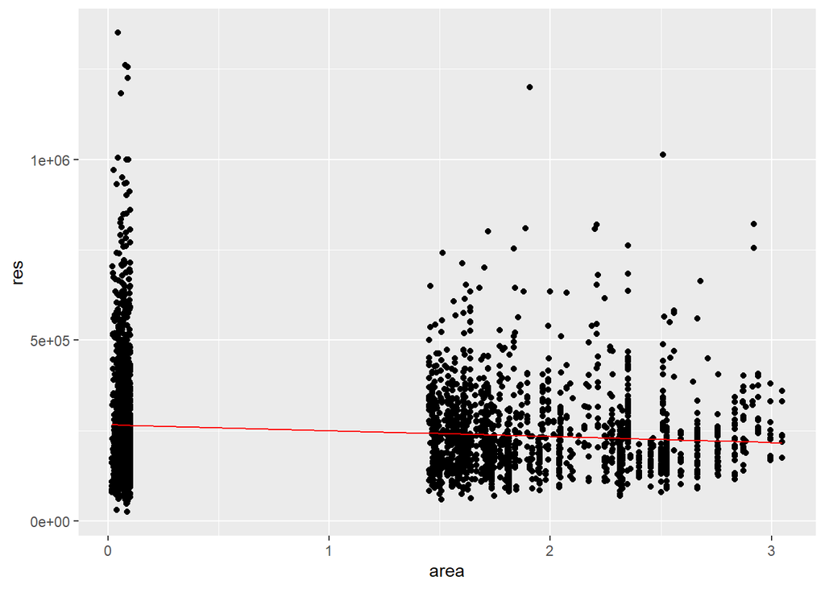

```r
b0 = coef(fit2)[1]
b1 = coef(fit2)[2]


res = b0 +  b1 * ndf$station_distance
new_df2 = data.frame(ndf$station_distance , res , stringsAsFactors = F)
colnames(new_df2) = c("area" , "res")

ggplot(data = new_df2, aes(x = area, y = res))+geom_point(mapping = aes(ndf$station_distance , ndf$price))+ geom_line(color='red',data = new_df2, aes(x=area, y=res))
```

the slope of the line is negative which is obvious why.(the further a house is located to a station, the cheaper this house will be.)

### 5

remember this plot :

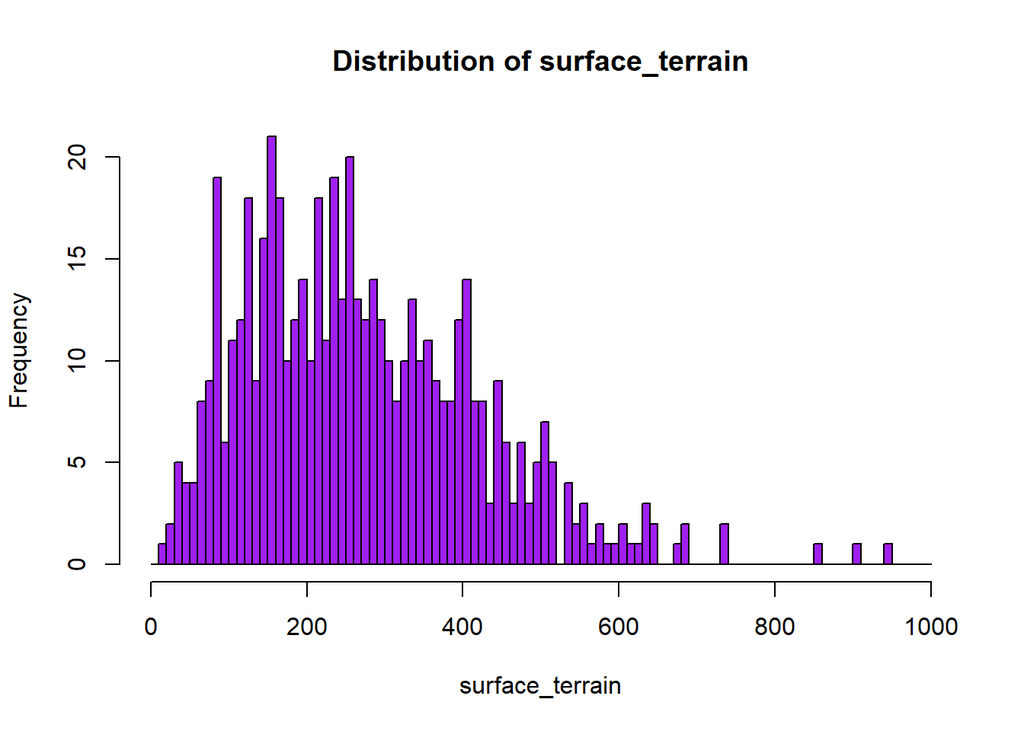

```r
t2 = a[a$surface_terrain!=0 , ]
hist(t2$surface_terrain , breaks = seq(0 , 1000 , 10) , col = "purple" , main="Distribution of surface_terrain" , xlab = "surface_terrain")
```

now let’s calculate a 95% confidence interval for mean of the whole population.

```r
n = (dim(t2))[1]
sigma = sd(t2$surface_terrain)
xbar = mean(t2$surface_terrain)
upper = xbar + 1.960 * (sigma/sqrt(n))
lower = xbar - 1.960 * (sigma/sqrt(n))

print(paste("[" , lower , "," , upper , "]"))
```

```
## [1] "[ 260.912761360807 , 286.185778785179 ]"
```

ok. now let’s test this result. we expect that the probability of mean of population to be 250, is low. if we run a z.test :

```r
 z.test(t2$surface_terrain, y = NULL , alternative = 'two.sided', mu = 250, sigma.x = sd(t2$surface_terrain), sigma.y = NULL , conf.level = 0.95)
```

```
##
##  One-sample z-Test
##
## data:  t2$surface_terrain
## z = 3.6526, p-value = 0.0002596
## alternative hypothesis: true mean is not equal to 250
## 95 percent confidence interval:
##  260.9130 286.1855
## sample estimates:
## mean of x
##  273.5493
```

ok. the p_value is low nad shows that our expectation is right.

### 6

we expect that maisons have larger housing_surface than appartements. so we test this hypothesis :

H0 : mean of surface_housing in maisons is equal to mean of surface_housing in appartements.

H1 : other wise.

```r
a$type_property = as.character(a$type_property)
r1 = a[a$type_property == "appartement" , ]
r2 = a[a$type_property == "maison" , ]

z.test(r2$surface_housing, y = r1$surface_housing , alternative = 'two.sided', mu = 0, sigma.x = sd(r2$surface_housing), sigma.y = sd(r1$surface_housing),conf.level = 0.95)
```

```
##
##  Two-sample z-Test
##
## data:  r2$surface_housing and r1$surface_housing
## z = 25.493, p-value < 2.2e-16
## alternative hypothesis: true difference in means is not equal to 0
## 95 percent confidence interval:
##  36.61843 42.71801
## sample estimates:
## mean of x mean of y
##  104.2288   64.5606
```

nice. the p-value is low and we can reject null hypothesis. so as we expect mean of surface_housing in maisons is really larger than mean of surface_housing in appartements.

### 7

let’s check if “area_price_ratio” and “district” has a relationship. we test this hypothesis by regression. in regression the null hypothesis is that two variables has no relationships.

```r
fit5 = lm(area_price_ratio~district , data = a)
summary(fit5)
```

```
##
## Call:
## lm(formula = area_price_ratio ~ district, data = a)
##
## Residuals:
##     Min      1Q  Median      3Q     Max
## -4106.2  -847.0   -98.4   759.6 31387.0
##
## Coefficients:
##                                Estimate Std. Error t value Pr(>|t|)
## (Intercept)                     4653.86      29.46 157.992   <2e-16 ***
## districtLyon 2e Arrondissement   369.98      44.19   8.373   <2e-16 ***
## districtLyon 3e Arrondissement  -489.72      33.65 -14.554   <2e-16 ***
## districtLyon 4e Arrondissement   -16.53      39.52  -0.418    0.676
## districtLyon 5e Arrondissement -1073.39      37.49 -28.628   <2e-16 ***
## districtLyon 6e Arrondissement   452.34      38.88  11.635   <2e-16 ***
## districtLyon 7e Arrondissement  -394.44      34.17 -11.544   <2e-16 ***
## districtLyon 8e Arrondissement  -874.57      34.79 -25.136   <2e-16 ***
## districtLyon 9e Arrondissement -1185.26      36.67 -32.323   <2e-16 ***
## districtVilleurbanne           -1290.89      31.95 -40.401   <2e-16 ***
## ---
## Signif. codes:  0 '***' 0.001 '**' 0.01 '*' 0.05 '.' 0.1 ' ' 1
##
## Residual standard error: 1256 on 40363 degrees of freedom
## Multiple R-squared:  0.1646, Adjusted R-squared:  0.1644
## F-statistic: 883.4 on 9 and 40363 DF,  p-value: < 2.2e-16
```

ok. the p_value of the test is really small. it means that there is a relationship between districts and area_price_ratio. but this relation is small. as we have seen earlier on a map :

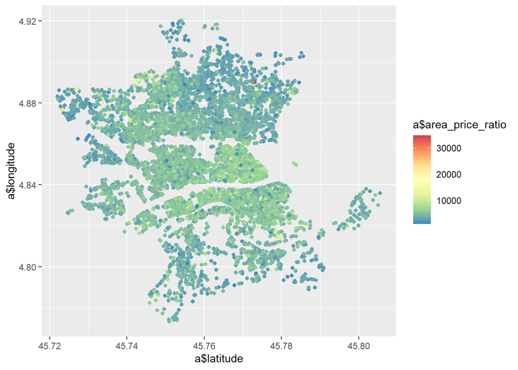

```r
ggplot()+geom_point(mapping = aes(x=a$latitude,y=a$longitude , color = a$area_price_ratio) )+scale_color_distiller(palette = 'Spectral')
```

here you can see that in the northeast of the city the prices are lower than center. but in total, this realtionship is small.(we can refer to R^2 value of regression.)

### 8

let’s have look at a previously plotted data :

```r
ggplot(df2, aes(x=year, y=price, group=district)) +
  geom_line(aes(color=district))+
  geom_point(aes(color=district))
```

[output not shown]

so let’s prepare for a regression.we are going to regress price of the house at time of transaction. suppose 2016/1 (jan) is set to be 1. we use data of district “Lyon 7e Arrondissement”. (it can be done for any other districts too. just change variable “dis” in part below.)

```r
dis = "Lyon 7e Arrondissement"
new_df = a[a$district==dis,]
new_df$year = as.numeric(new_df$year)
new_df$month = as.numeric(new_df$month)
new_df$time = (new_df$year -2016)*12 + new_df$month
fit = lm(price~time , data = new_df)
summary(fit)
```

```
##
## Call:
## lm(formula = price ~ time, data = new_df)
##
## Residuals:
##     Min      1Q  Median      3Q     Max
## -245333  -81659  -15342   61653 1007833
##
## Coefficients:
##              Estimate Std. Error t value Pr(>|t|)
## (Intercept) 193697.42    3628.41   53.38   <2e-16 ***
## time          1665.99      99.59   16.73   <2e-16 ***
## ---
## Signif. codes:  0 '***' 0.001 '**' 0.01 '*' 0.05 '.' 0.1 ' ' 1
##
## Residual standard error: 114600 on 5262 degrees of freedom
## Multiple R-squared:  0.0505, Adjusted R-squared:  0.05032
## F-statistic: 279.9 on 1 and 5262 DF,  p-value: < 2.2e-16
```

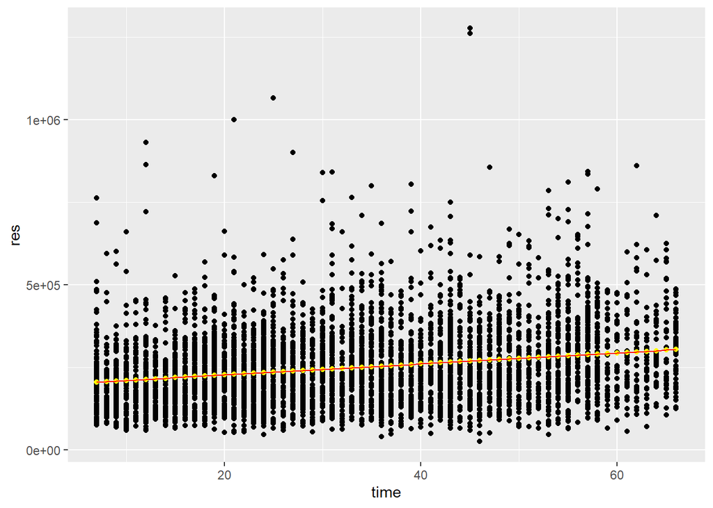

```r
b0 = coef(fit)[1]
b1 = coef(fit)[2]


res = b0 +  b1 * new_df$time
new_df2 = data.frame(new_df$time , res , stringsAsFactors = F)
colnames(new_df2) = c("time" , "res")

ggplot(data = new_df2, aes(x = time, y = res))+geom_point(mapping = aes(new_df$time , new_df$price))+ geom_point(color='yellow')+ geom_line(color='red',data = new_df, aes(x=time, y=res))
```

as we expect , the slope of the regresiion line is possitive and it shows that by passing time , price of houses are increased.

### 9

as we saw before :

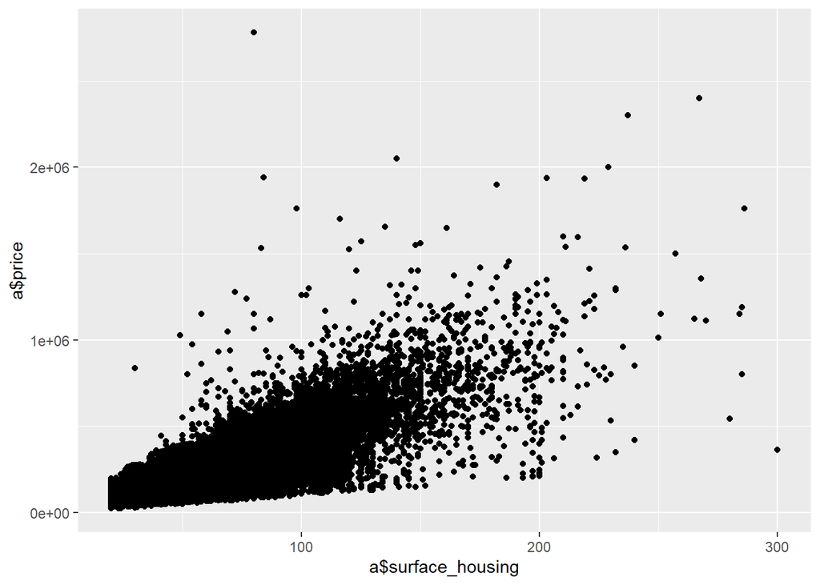

```r
ggplot() + geom_point(mapping = aes(a$surface_housing , a$price))
```

```r
fit2 = lm(price ~ surface_housing , data = a)
summary(fit2)
```

```
##
## Call:
## lm(formula = price ~ surface_housing, data = a)
##
## Residuals:
##     Min      1Q  Median      3Q     Max
## -852973  -57388   -1768   50073 2463692
##
## Coefficients:
##                  Estimate Std. Error t value Pr(>|t|)
## (Intercept)     -11056.18    1285.94  -8.598   <2e-16 ***
## surface_housing   4092.05      18.09 226.146   <2e-16 ***
## ---
## Signif. codes:  0 '***' 0.001 '**' 0.01 '*' 0.05 '.' 0.1 ' ' 1
##
## Residual standard error: 102600 on 40371 degrees of freedom
## Multiple R-squared:  0.5588, Adjusted R-squared:  0.5588
## F-statistic: 5.114e+04 on 1 and 40371 DF,  p-value: < 2.2e-16
```

as we can see, p-values are really small and t-values are really big, so we can reject null hypothesis of regression.(null hypothesis: there is no relationship between surface_housing and price.)

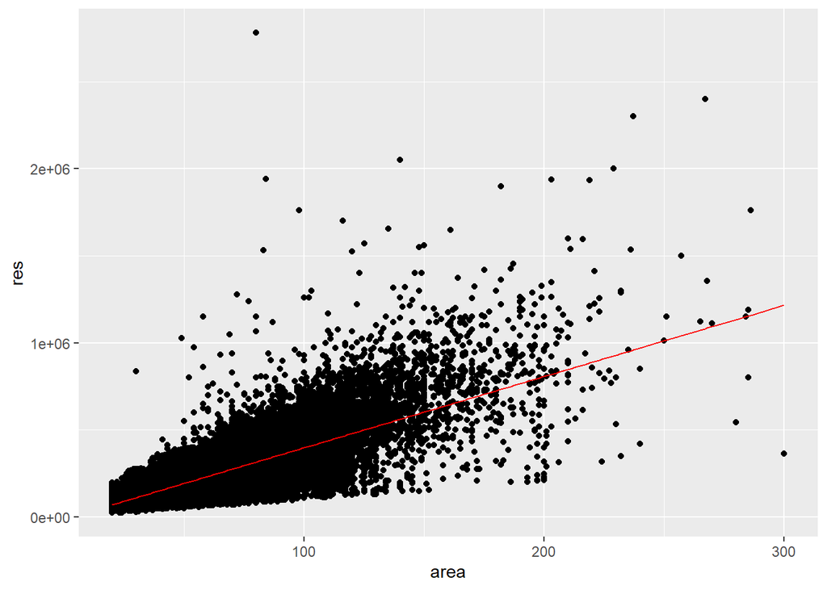

```r
b0 = coef(fit2)[1]
b1 = coef(fit2)[2]


res = b0 +  b1 * a$surface_housing
new_df2 = data.frame(a$surface_housing , res , stringsAsFactors = F)
colnames(new_df2) = c("area" , "res")

ggplot(data = new_df2, aes(x = area, y = res))+geom_point(mapping = aes(a$surface_housing , a$price))+ geom_line(color='red',data = new_df2, aes(x=area, y=res))
```

it seems good. we expect that a larger house cost more money and the slope of our regression line proved our expection.